# TSK_NLP_Project_Full_Code-1_CLEANED

## **Problem Statement**

### Business Context

The prices of the stocks of companies listed under a global exchange are influenced by a variety of factors, with the company's financial performance, innovations and collaborations, and market sentiment being factors that play a significant role. News and media reports can rapidly affect investor perceptions and, consequently, stock prices in the highly competitive financial industry. With the sheer volume of news and opinions from a wide variety of sources, investors and financial analysts often struggle to stay updated and accurately interpret its impact on the market. As a result, investment firms need sophisticated tools to analyze market sentiment and integrate this information into their investment strategies.

### Problem Definition

With an ever-rising number of news articles and opinions, an investment startup aims to leverage artificial intelligence to address the challenge of interpreting stock-related news and its impact on stock prices. They have collected historical daily news for a specific company listed under NASDAQ, along with data on its daily stock price and trade volumes.

As a member of the Data Science and AI team in the startup, you have been tasked with analyzing the data, developing an AI-driven sentiment analysis system that will automatically process and analyze news articles to gauge market sentiment, and summarizing the news at a weekly level to enhance the accuracy of their stock price predictions and optimize investment strategies. This will empower their financial analysts with actionable insights, leading to more informed investment decisions and improved client outcomes.

### Data Dictionary

- `Date` : The date the news was released
- `News` : The content of news articles that could potentially affect the company's stock price
- `Open` : The stock price (in $) at the beginning of the day
- `High` : The highest stock price (in $) reached during the day
- `Low` : The lowest stock price (in $) reached during the day
- `Close` : The adjusted stock price (in $) at the end of the day
- `Volume` : The number of shares traded during the day
- `Label` : The sentiment polarity of the news content
  - 1: positive
  - 0: neutral
  - -1: negative

## **Installing and Importing Necessary Libraries**

```python
# installing the sentence-transformers and gensim libraries for word embeddings
!pip install -U scipy sentence-transformers gensim transformers tqdm huggingface_hub[hf_xet] -q
```

```python
# to read and manipulate the data
import pandas as pd
import numpy as np
pd.set_option('max_colwidth', None)    # setting column to the maximum column width as per the data

# to visualise data
import matplotlib.pyplot as plt
import matplotlib.dates as mdates
import seaborn as sns

# to compute distances
from scipy.spatial.distance import cdist, pdist
from sklearn.metrics import silhouette_score

# importing the PyTorch Deep Learning library
import torch

# to use regular expressions for manipulating text data
import re

# to import the model
from sentence_transformers import SentenceTransformer

# to cluster the data
from sklearn.cluster import KMeans

# To build a Random Forest model
from sklearn.ensemble import RandomForestClassifier

# To tune a model
from sklearn.model_selection import GridSearchCV
from sklearn.model_selection import RandomizedSearchCV

# To compute metrics to evaluate the model
from sklearn.metrics import accuracy_score, classification_report, confusion_matrix,recall_score,precision_score,f1_score

# to load the natural language toolkit
import nltk
nltk.download('stopwords')    # loading the stopwords
nltk.download('wordnet')    # loading the wordnet module that is used in stemming

# to remove common stop words
from nltk.corpus import stopwords

# to visualize text data using wordcloud
# from wordcloud import STOPWORDS

# to perform stemming
from nltk.stem.porter import PorterStemmer

# To import Word2Vec
from gensim.models import Word2Vec

# to avoid displaying unnecessary warnings
import warnings
warnings.filterwarnings("ignore")
```

## **Loading the dataset**

```python
from google.colab import drive
drive.mount('/content/drive')
```

```python
stocknews = pd.read_csv("/content/drive/MyDrive/Data/Stock_Market_News_Sentiment_Analysis_and_Summarization/stock_news.csv")
```

```python
# creating a copy of the dataset
data = stocknews.copy()
```

## **Data Overview**

### Checking the first five rows of the data

```python
# Print first 5 rows of data
data.head()
```

|  | Date | News | Open | High | Low | Close | Volume | Label |
| --- | --- | --- | --- | --- | --- | --- | --- | --- |
| 0 | 2019-01-02 | The tech sector experienced a significant decline in the aftermarket following Apple's Q1 revenue warning. Notable suppliers, including Skyworks, Broadcom, Lumentum, Qorvo, and TSMC, saw their stocks … | 41.740002 | 42.244999 | 41.482498 | 40.246914 | 130672400 | -1 |
| 1 | 2019-01-02 | Apple lowered its fiscal Q1 revenue guidance to $84 billion from earlier estimates of $89-$93 billion due to weaker than expected iPhone sales. The announcement caused a significant drop in Apple's st… | 41.740002 | 42.244999 | 41.482498 | 40.246914 | 130672400 | -1 |
| 2 | 2019-01-02 | Apple cut its fiscal first quarter revenue forecast from $89-$93 billion to $84 billion due to weaker demand in China and fewer iPhone upgrades. CEO Tim Cook also mentioned constrained sales of Airpod… | 41.740002 | 42.244999 | 41.482498 | 40.246914 | 130672400 | -1 |
| 3 | 2019-01-02 | This news article reports that yields on long-dated U.S. Treasury securities hit their lowest levels in nearly a year on January 2, 2019, due to concerns about the health of the global economy followi… | 41.740002 | 42.244999 | 41.482498 | 40.246914 | 130672400 | -1 |
| 4 | 2019-01-02 | Apple's revenue warning led to a decline in USD JPY pair and a gain in Japanese yen, as investors sought safety in the highly liquid currency. Apple's underperformance in Q1, with forecasted revenue o… | 41.740002 | 42.244999 | 41.482498 | 40.246914 | 130672400 | -1 |

### Checking the last five rows of the data

```python
# Print last 5 rows of data
data.tail()
```

|  | Date | News | Open | High | Low | Close | Volume | Label |
| --- | --- | --- | --- | --- | --- | --- | --- | --- |
| 344 | 2019-04-30 | Media mogul Oprah Winfrey, known for influencing millions with her opinions on diets and books, is considering which Democratic presidential candidate to endorse in 2020. She told the Hollywood Report… | 50.764999 | 50.849998 | 49.7775 | 48.70879 | 186139600 | -1 |
| 345 | 2019-04-30 | European shares fell on Tuesday, with banks underperforming amid a decline in China's manufacturing activity and awaiting euro zone economic growth numbers. The pan-European STOXX 600 index dropped 0.… | 50.764999 | 50.849998 | 49.7775 | 48.70879 | 186139600 | -1 |
| 346 | 2019-04-30 | This article reports that the S&P 500 reached another record high close on Tuesday, marking its best four-month stretch since late 2010. Apple's strong quarterly results and positive earnings forecast… | 50.764999 | 50.849998 | 49.7775 | 48.70879 | 186139600 | -1 |
| 347 | 2019-04-30 | The Federal Reserve is anticipated to keep interest rates unchanged in their upcoming meeting, with a likelihood of a rate cut expected later this year. The Fed Chairman's press conference may provide… | 50.764999 | 50.849998 | 49.7775 | 48.70879 | 186139600 | -1 |
| 348 | 2019-04-30 | In the first quarter, South Korea's Samsung Electronics reported its weakest profit in over two years due to falls in chip prices and slowing demand for display panels. The tech giant expects improved… | 50.764999 | 50.849998 | 49.7775 | 48.70879 | 186139600 | 0 |

### Checking the shape of the dataset

```python
data.shape
```

```
(349, 8)
```

- The data has 349 stock news

### Checking for missing values

```python
# Check for missing values
data.isnull().sum()
```

|  | 0 |
| --- | --- |
| Date | 0 |
| News | 0 |
| Open | 0 |
| High | 0 |
| Low | 0 |
| Close | 0 |
| Volume | 0 |
| Label | 0 |

**dtype:** int64

- There are no missing values in the data.

### Checking for duplicate values

```python
# Check for duplicate values
data.duplicated().sum()
```

```
0
```

- There are no duplicate values in the data.

### Checking the attribute types

```python
# Check the data type of the columns
data.info()
```

```
<class 'pandas.core.frame.DataFrame'>
RangeIndex: 349 entries, 0 to 348
Data columns (total 8 columns):
 #   Column  Non-Null Count  Dtype
---  ------  --------------  -----
 0   Date    349 non-null    object
 1   News    349 non-null    object
 2   Open    349 non-null    float64
 3   High    349 non-null    float64
 4   Low     349 non-null    float64
 5   Close   349 non-null    float64
 6   Volume  349 non-null    int64
 7   Label   349 non-null    int64
dtypes: float64(4), int64(2), object(2)
memory usage: 21.9+ KB
```

- There are 6 numeric and 2 categorical columns in the data.
- `Date` should be converted to datetime format for exploratory data analysis.
- `Label` should be treated as a categorical columns.

### Fixing the data types

```python
# convert the 'Date' type from object to datetime format
data['Date'] = pd.to_datetime(data['Date'])
```

### Checking the statistical summary

```python
# Check the statistical summary for numerical features
data.describe().T
```

|  | count | mean | min | 25% | 50% | 75% | max | std |
| --- | --- | --- | --- | --- | --- | --- | --- | --- |
| Date | 349 | 2019-02-16 16:05:30.085959936 | 2019-01-02 00:00:00 | 2019-01-14 00:00:00 | 2019-02-05 00:00:00 | 2019-03-22 00:00:00 | 2019-04-30 00:00:00 | NaN |
| Open | 349.0 | 46.229233 | 37.567501 | 41.740002 | 45.974998 | 50.7075 | 66.817497 | 6.442817 |
| High | 349.0 | 46.700458 | 37.817501 | 42.244999 | 46.025002 | 50.849998 | 67.0625 | 6.507321 |
| Low | 349.0 | 45.745394 | 37.305 | 41.482498 | 45.639999 | 49.7775 | 65.862503 | 6.391976 |
| Close | 349.0 | 44.926317 | 36.254131 | 40.246914 | 44.596924 | 49.11079 | 64.805229 | 6.398338 |
| Volume | 349.0 | 128948236.103152 | 45448000.0 | 103272000.0 | 115627200.0 | 151125200.0 | 244439200.0 | 43170314.918964 |
| Label | 349.0 | -0.054441 | -1.0 | -1.0 | 0.0 | 0.0 | 1.0 | 0.715119 |

### Data Engineering

```python
# Add a new attribute to calculate the news article lenght for EDA
data['News_Length'] = data['News'].apply(len)
```

```python
data['News_Length']
```

|  | News_Length |
| --- | --- |
| 0 | 324 |
| 1 | 323 |
| 2 | 296 |
| 3 | 300 |
| 4 | 305 |
| ... | ... |
| 344 | 299 |
| 345 | 274 |
| 346 | 315 |
| 347 | 383 |
| 348 | 314 |

349 rows × 1 columns

**dtype:** int64

## **Exploratory Data Analysis**

**The below functions need to be defined to carry out the EDA.**

```python
def histogram_boxplot(data, feature, figsize=(15, 10), kde=False, bins=None):
    """
    Boxplot and histogram combined

    data: dataframe
    feature: dataframe column
    figsize: size of figure (default (15,10))
    kde: whether to show the density curve (default False)
    bins: number of bins for histogram (default None)
    """
    f2, (ax_box2, ax_hist2) = plt.subplots(
        nrows=2,  # Number of rows of the subplot grid= 2
        sharex=True,  # x-axis will be shared among all subplots
        gridspec_kw={"height_ratios": (0.25, 0.75)},
        figsize=figsize,
    )  # creating the 2 subplots
    sns.boxplot(
        data=data, x=feature, ax=ax_box2, showmeans=True, color="violet"
    )  # boxplot will be created and a triangle will indicate the mean value of the column
    sns.histplot(
        data=data, x=feature, kde=kde, ax=ax_hist2, bins=bins
    ) if bins else sns.histplot(
        data=data, x=feature, kde=kde, ax=ax_hist2
    )  # For histogram
    ax_hist2.axvline(
        data[feature].mean(), color="green", linestyle="--"
    )  # Add mean to the histogram
    ax_hist2.axvline(
        data[feature].median(), color="black", linestyle="-"
    )  # Add median to the histogram
```

```python
# function to create labeled barplots
def labeled_barplot(data, feature, perc=False, n=None):
    """
    Barplot with percentage at the top

    data: dataframe
    feature: dataframe column
    perc: whether to display percentages instead of count (default is False)
    n: displays the top n category levels (default is None, i.e., display all levels)
    """

    total = len(data[feature])  # length of the column
    count = data[feature].nunique()
    if n is None:
        plt.figure(figsize=(count + 2, 6))
    else:
        plt.figure(figsize=(n + 2, 6))

    plt.xticks(rotation=90, fontsize=15)
    ax = sns.countplot(
        data=data,
        x=feature,
        palette="Paired",
        order=data[feature].value_counts().index[:n],
    )

    for p in ax.patches:
        if perc == True:
            label = "{:.1f}%".format(
                100 * p.get_height() / total
            )  # percentage of each class of the category
        else:
            label = p.get_height()  # count of each level of the category

        x = p.get_x() + p.get_width() / 2  # width of the plot
        y = p.get_height()  # height of the plot

        ax.annotate(
            label,
            (x, y),
            ha="center",
            va="center",
            size=12,
            xytext=(0, 5),
            textcoords="offset points",
        )  # annotate the percentage

    plt.show()  # show the plot
```

```python
# Function to get a dominant sentiment based on the news in a given day
def get_dominant_sentiment(series):
    mode = series.mode()
    return mode[0] if not mode.empty else None
```

### Univariate Analysis

- Distribution of individual variables
- Compute and check the distribution of the length of news content

#### `Open`

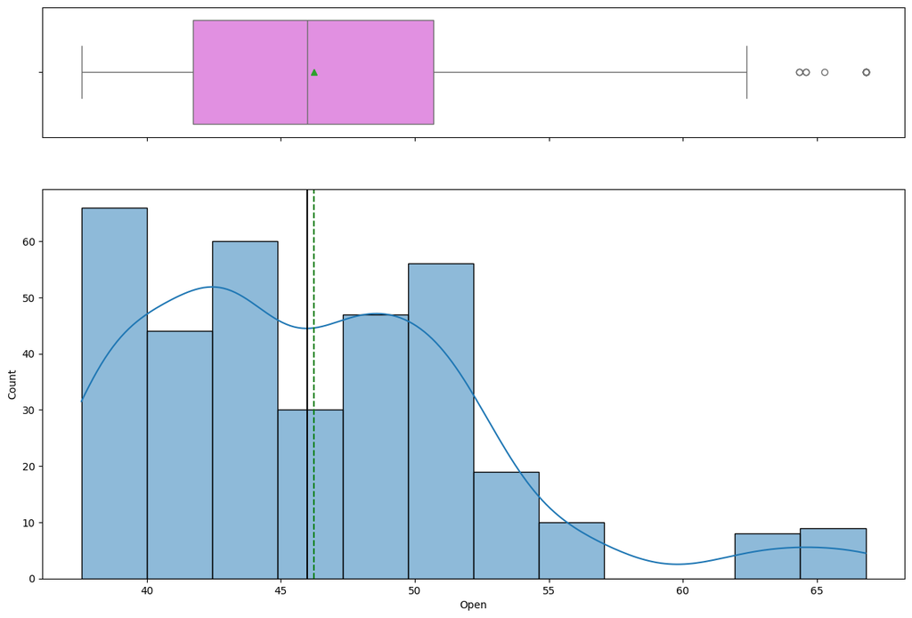

```python
histogram_boxplot(data, 'Open', figsize=(15, 10),kde=True)
```

- The distribution is right skewed.
- There are ouliers in the higher end.

#### `High`

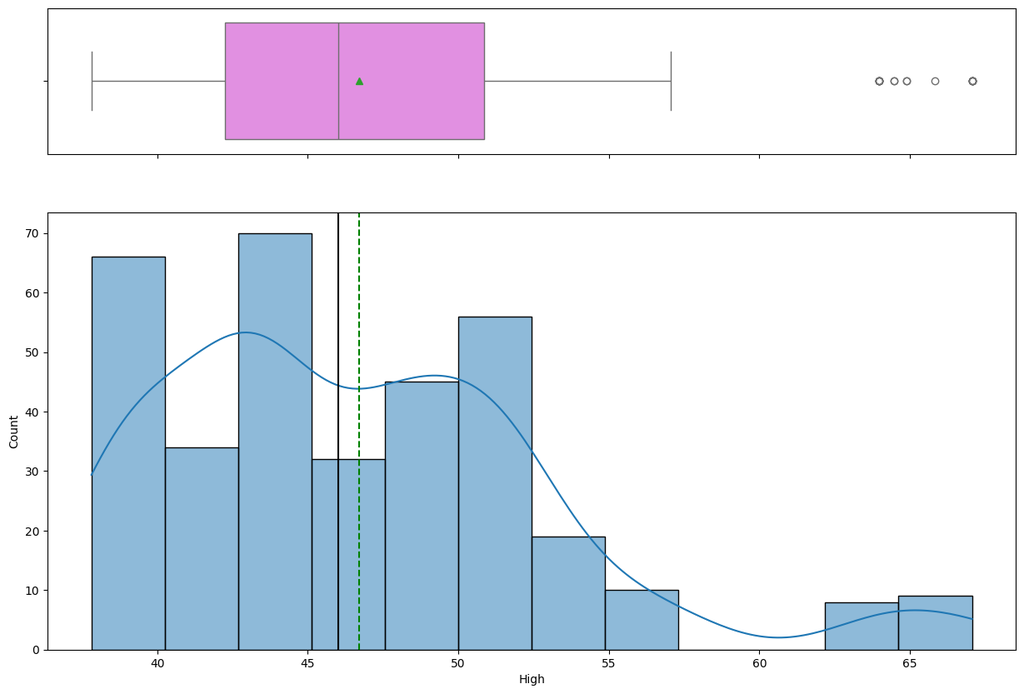

```python
histogram_boxplot(data, 'High', figsize=(15, 10),kde=True)
```

- The distribution is right skewed.
- There are ouliers in the higher end.

#### `Low`

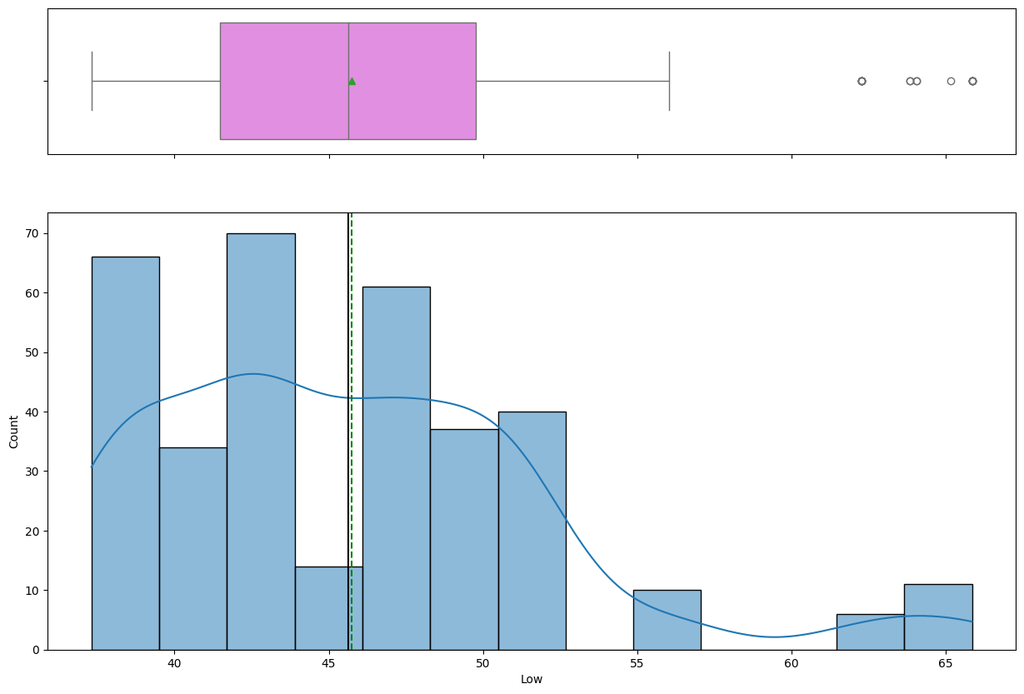

```python
histogram_boxplot(data, 'Low', figsize=(15, 10),kde=True)
```

- The distribution is right skewed.
- There are ouliers in the higher end.

#### `Close`

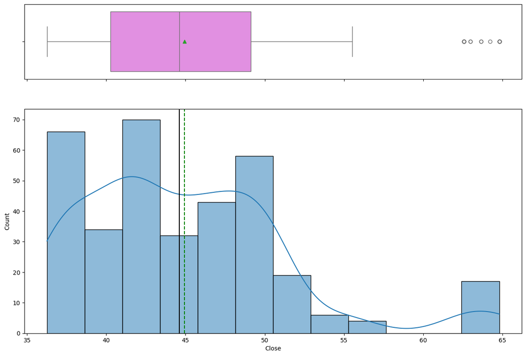

```python
histogram_boxplot(data, 'Close', figsize=(15, 10),kde=True)
```

- The distribution is right skewed.
- There are ouliers in the higher end.

#### `Volume`

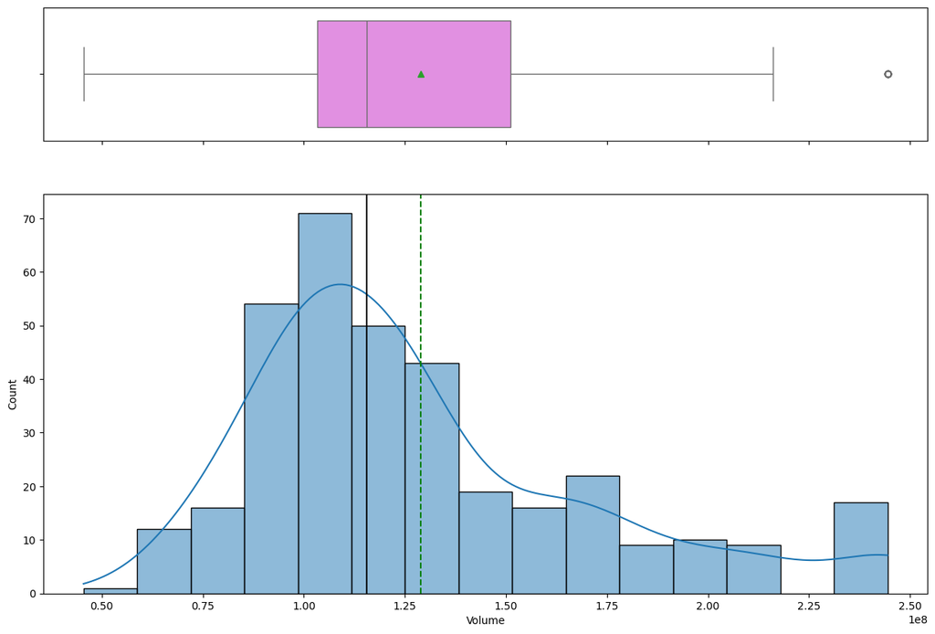

```python
histogram_boxplot(data, 'Volume', figsize=(15, 10),kde=True)
```

- The distribution is right skewed.
- There are ouliers in the higher end.

#### `Label`

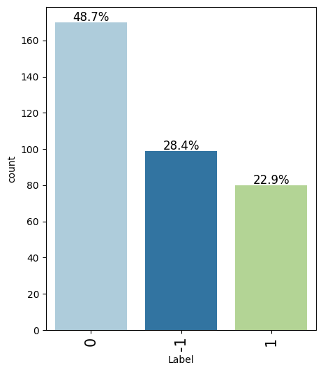

```python
labeled_barplot(data, 'Label', perc=True)
```

- **Neutral:** The majority of the news articles are labeled as neutral (0), accounting for approximately 48.7% of the dataset.
- **Comparable negative and positive sentiment:** The counts for negative (-1) and positive (+1) news articles are relatively similar, representing around 28.4% and 22.9% of the data, respectively.
- **Imbalanced distribution:** The distribution is not balanced, with neutral news significantly outnumbering both negative and positive news.

#### `Date`

[figure not shown]

```python
labeled_barplot(data, 'Date', perc=False)
```

- **Peak news day:** The highest volume of shared news articles occurred on 2019-01-03, with a maximum of 28 articles
- **High variability in news volume:** There's a significant disparity in the number of news articles shared per day, ranging from a high of 28 down to days with only one or two articles.

#### 'News_Length'

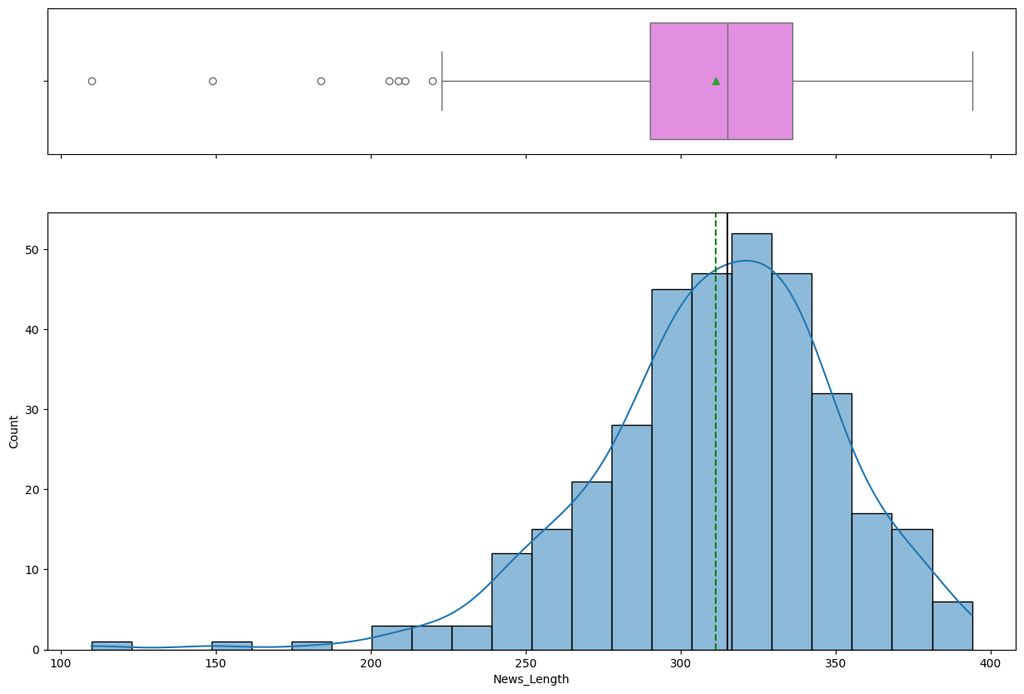

```python
histogram_boxplot(data, 'News_Length', figsize=(15, 10),kde=True)
```

- The distribution of news length is left skewed.
- There are outliers in the lower end (very short news).

### Bivariate Analysis

#### Correlation

```python
# Define Numeric features
numeric_features = ['Open', 'High', 'Low', 'Close', 'Volume', 'News_Length']
```

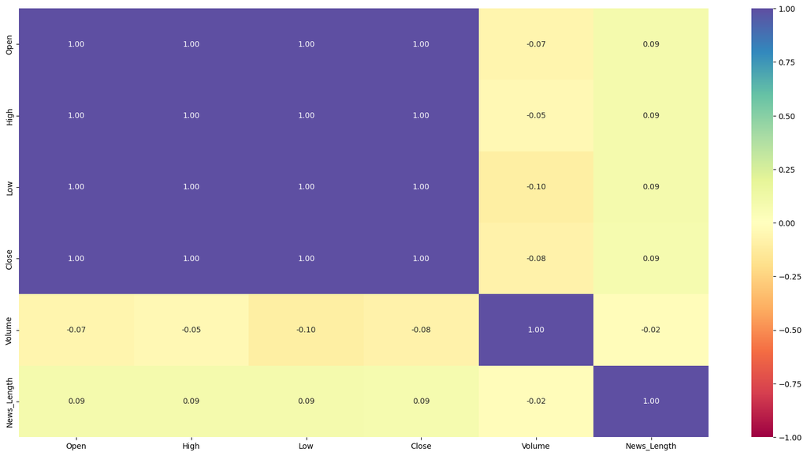

```python
plt.figure(figsize=(20,10))
sns.heatmap(data[numeric_features].corr(),annot=True,vmin=-1,vmax=1,fmt='.2f',cmap="Spectral")
plt.show()
```

- **Very Strong Positive Correlation:** `Open`, `High`, `Low`, and `Close` prices forthe stock are very strongly correlated.
- **Weak Negative Correlation:** `Volume` has a weak negative correlation with `Open`, `High`, `Low`, and `Close` prices (correlation around -0.05 to -0.10).
- **Weak Positive Correlation:** `News_Length` with `Open`, `High`, `Low`, and `Close` prices (correlation around 0.09).
- **Very Weak Correlation:** `Volume` with `News_Length` (correlation around -0.02).

#### News Sentiment (`Label`) vs Price features (`Open`,`Close`,`High`,`Low`)

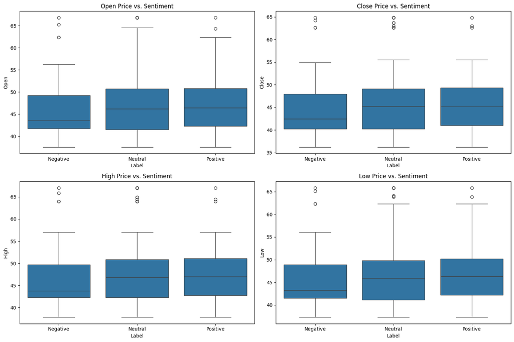

```python
# Box Plots for price features against news sentiment
price_features = ['Open', 'Close', 'High', 'Low']
# Copy data to temp df for replacing the Label values
temp_df = data.copy()
# Replace the Label values
temp_df['Label'] = temp_df['Label'].replace({-1: 'Negative', 0: 'Neutral', 1: 'Positive'})

plt.figure(figsize=(15, 10))
for i, feature in enumerate(price_features):
    plt.subplot(2, 2, i + 1)
    sns.boxplot(x='Label', y=feature, data=temp_df)
    plt.title(f'{feature} Price vs. Sentiment')
plt.tight_layout()
plt.show()
```

- Days with neutral or positive news showed largely similar price patterns for `Open`, `Close`, `High`, and `Low`.
- When the news was negative, all the prices (`Open`, `Close`, `High`, and `Low`) tended to be a bit lower, and the range during the day was generally smaller.

#### News Sentiment (`Label`) vs `Volume`

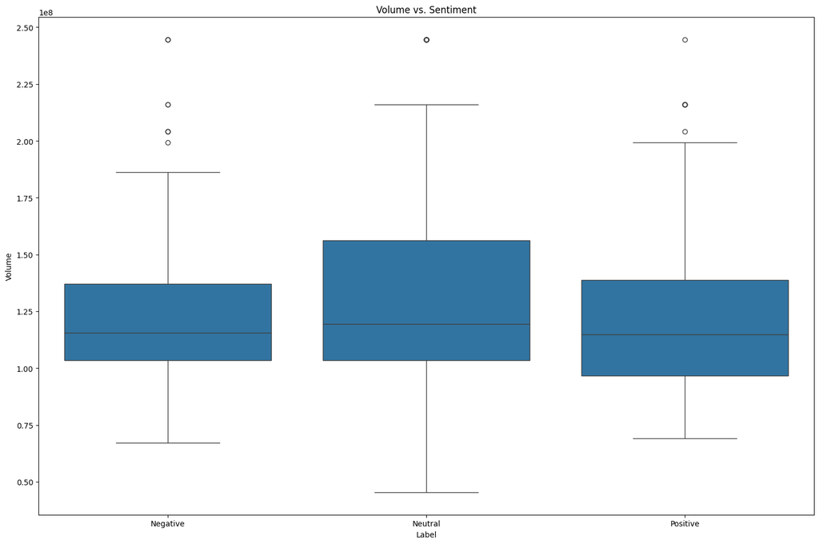

```python
# Box Plot for volume against news sentiment

plt.figure(figsize=(15, 10))
sns.boxplot(x='Label', y='Volume', data=temp_df)
plt.title('Volume vs. Sentiment')
plt.tight_layout()
plt.show()
```

- Trading Volume Range by Sentiment:
  - Neutral: Exhibited the widest range of trading volume.
  - Positive: Showed a moderate range of trading volume.
  - Negative: Displayed the narrowest range of trading volume.
- Unusually high trading happened slightly more often on negative and positive news days.

#### News Sentiment (`Label`) vs `Date`

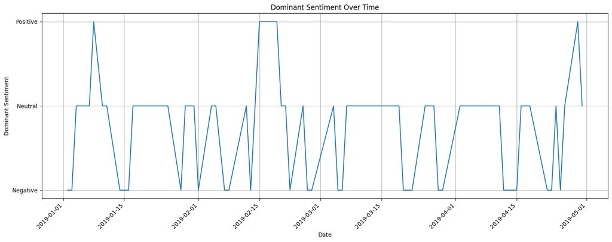

```python
# Time Series of Dominant Sentiment (Line Plot - using mode)

dominant_sentiment = temp_df.groupby('Date')['Label'].agg(get_dominant_sentiment)
plt.figure(figsize=(15, 6))
plt.plot(dominant_sentiment.index, dominant_sentiment.values)
plt.title('Dominant Sentiment Over Time')
plt.xlabel('Date')
plt.ylabel('Dominant Sentiment')
plt.xticks(rotation=45, ha='right')
plt.grid(True)
plt.tight_layout()
plt.show()
```

- Dominant news sentiment changed often, with neutral being most common and positive/negative appearing in shorter periods.

#### `Date` vs Price features (`Open`,`Close`,`High`,`Low`)

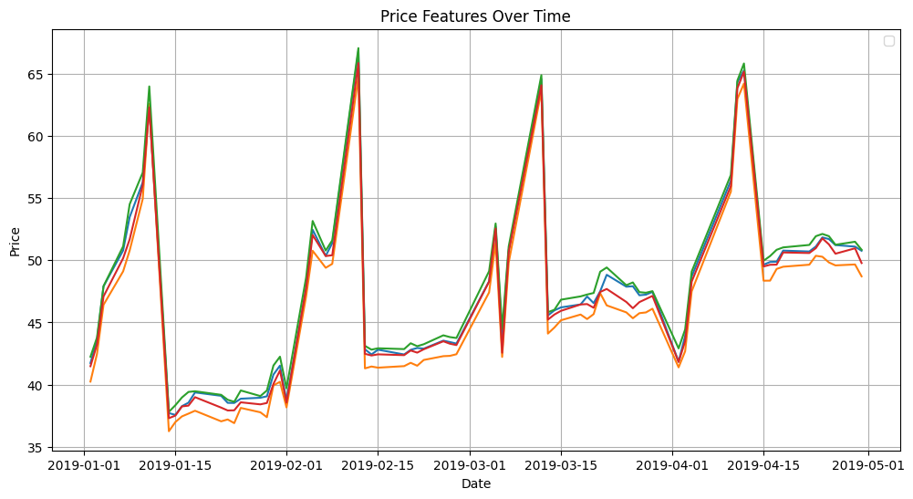

```python
# All on One Plot
plt.figure(figsize=(12, 6))
for feature in price_features:
    plt.plot(temp_df['Date'], temp_df[feature])
plt.xlabel('Date')
plt.ylabel('Price')
plt.title('Price Features Over Time')
plt.legend()
plt.grid(True)
#plt.gca().xaxis.set_major_locator(mdates.DayLocator(interval=5)) # Show tick for every day
#plt.gcf().autofmt_xdate() # Automatically format date labels (often includes rotation)
#plt.tight_layout()
plt.show()
```

- `Open`, `Close`, `High`, and `Low` prices moved together closely, showing a strong positive correlation.
- The daily difference between the `High` and `Low` price remained fairly consistent, indicating stable daily volatility.
- Prices showed significant ups and downs with observable trends throughout the four months.
- Sharp spikes and dips occurred across all prices at the same time, likely due to market events or news.

#### `Date` vs `Volume`

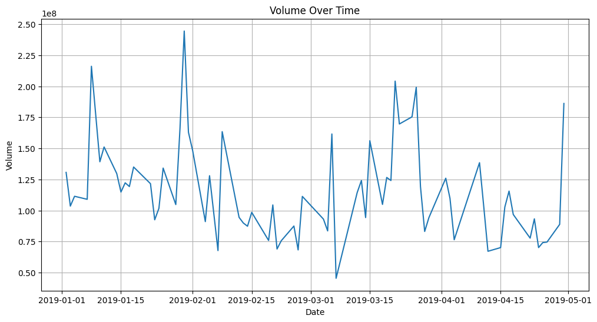

```python
# Volume Plot against Date
plt.figure(figsize=(12, 6))

plt.plot(temp_df['Date'], temp_df['Volume'], label=feature)
plt.xlabel('Date')
plt.ylabel('Volume')
plt.title('Volume Over Time')
#plt.legend()
plt.grid(True)
#plt.gca().xaxis.set_major_locator(mdates.DayLocator(interval=5)) # Show tick for every day
#plt.gcf().autofmt_xdate() # Automatically format date labels (often includes rotation)
#plt.tight_layout()
plt.show()
```

- Trading volume fluctuated significantly throughout the four-month period.
- There were occasional sharp spikes in volume, indicating periods of high trading activity.

#### `Date` vs Price features (`Open`,`Close`,`High`,`Low`) and `Volume`

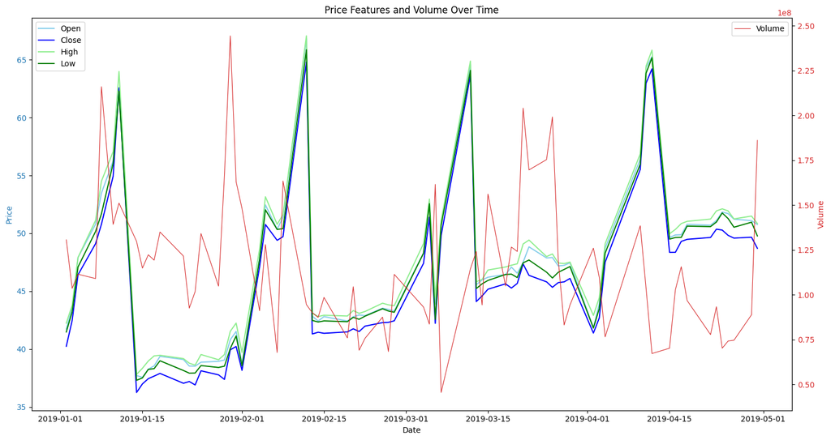

```python
# Plot price features and volumne against the time
fig, ax1 = plt.subplots(figsize=(15, 8))

# Plot Price Features
color = 'tab:blue'
ax1.set_xlabel('Date')
ax1.set_ylabel('Price', color=color)
ax1.plot(temp_df['Date'], temp_df['Open'], color='skyblue', label='Open')
ax1.plot(temp_df['Date'], temp_df['Close'], color='blue', label='Close')
ax1.plot(temp_df['Date'], temp_df['High'], color='lightgreen', label='High')
ax1.plot(temp_df['Date'], temp_df['Low'], color='green', label='Low')
ax1.tick_params(axis='y', labelcolor=color)
ax1.legend(loc='upper left')

# Create a second y-axis for Volume
ax2 = ax1.twinx()
color = 'tab:red'
ax2.set_ylabel('Volume', color=color)
ax2.plot(temp_df['Date'], temp_df['Volume'], color=color, label='Volume', linewidth=0.8)
ax2.tick_params(axis='y', labelcolor=color)
ax2.legend(loc='upper right')

plt.title('Price Features and Volume Over Time')
fig.tight_layout()
plt.show()
```

- Big jumps in price often happened when more shares were traded.
- Sharp price drops also sometimes saw more trading activity.
- However, high trading volume didn't always lead to big price changes, suggesting other factors also influenced the price.

#### `Date` vs Price features (`Open`,`Close`,`High`,`Low`), `Volume` and Sentiment (`Label`)

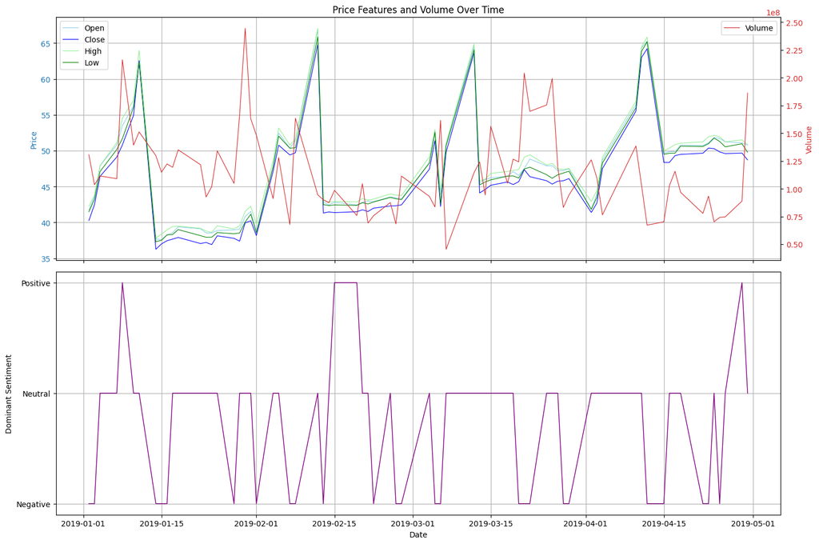

```python
dominant_sentiment = temp_df.groupby('Date')['Label'].agg(get_dominant_sentiment)

fig, axes = plt.subplots(nrows=2, ncols=1, figsize=(15, 10), sharex=True)

# Top subplot: Price Features and Volume
ax1 = axes[0]
color = 'tab:blue'
ax1.set_ylabel('Price', color=color)
ax1.plot(temp_df['Date'], temp_df['Open'], color='skyblue', label='Open', linewidth=0.8)
ax1.plot(temp_df['Date'], temp_df['Close'], color='blue', label='Close', linewidth=0.8)
ax1.plot(temp_df['Date'], temp_df['High'], color='lightgreen', label='High', linewidth=0.8)
ax1.plot(temp_df['Date'], temp_df['Low'], color='green', label='Low', linewidth=0.8)
ax1.tick_params(axis='y', labelcolor=color)
ax1.legend(loc='upper left')
ax1_twin = ax1.twinx()
color = 'tab:red'
ax1_twin.set_ylabel('Volume', color=color)
ax1_twin.plot(temp_df['Date'], temp_df['Volume'], color=color, label='Volume', linewidth=0.8)
ax1_twin.tick_params(axis='y', labelcolor=color)
ax1_twin.legend(loc='upper right')
ax1.set_title('Price Features and Volume Over Time')
ax1.grid(True)

# Bottom subplot: Dominant Sentiment
ax2 = axes[1]
ax2.plot(dominant_sentiment.index, dominant_sentiment.values, color='purple', linewidth=1)
ax2.set_xlabel('Date')
ax2.set_ylabel('Dominant Sentiment')
ax2.grid(True)

plt.xticks(rotation=45, ha='right')
fig.tight_layout()
plt.show()
```

- Stock prices ('Open', 'Close', 'High' and 'Low') often increased after positive news and decreased after negative news.
- Price changes on neutral days likely due to other other factors.

## **Data Preprocessing**

```python
# Review the data spread
# Count by month
data['YearMonth'] = data['Date'].dt.to_period('M')
monthly_counts = data['YearMonth'].value_counts().sort_index()
print("Counts by Month:\n", monthly_counts)

# Count by a specific time window (e.g., weekly)
data['YearWeek'] = data['Date'].dt.isocalendar().week
weekly_counts = data['YearWeek'].value_counts().sort_index()
print("\nCounts by Week:\n", weekly_counts)
```

```
Counts by Month:
 YearMonth
2019-01    166
2019-02     53
2019-03     67
2019-04     63
Freq: M, Name: count, dtype: int64

Counts by Week:
 YearWeek
1     52
2     31
3     29
4     21
5     36
6     15
7     18
8      8
9      9
10    10
11    16
12    18
13    23
14    12
15     7
16    20
17    12
18    12
Name: count, dtype: Int64
```

### Train Test Validation Data Split

```python
# Use approximately 70% of the data for training
train_end_date = '2019-03-15' # Mid-March

# Use approximately 15% of the data for validation
val_end_date = '2019-04-04'   # Mid March to first week of April

# Use approximately 15% of the data for testing
test_start_date = '2019-04-05' # End of first week of April till month end

X_train = data[data['Date'] <= train_end_date].reset_index(drop=True)
X_val = data[(data['Date'] > train_end_date) & (data['Date'] <= val_end_date)].reset_index(drop=True)
X_test = data[data['Date'] >= test_start_date].reset_index(drop=True)

print(f"Train set size: {len(X_train)}, Split: {len(X_train)/len(data)* 100:.2f} %")
print(f"Validation set size: {len(X_val)}, Split: {len(X_val)/len(data)* 100:.2f} %")
print(f"Test set size: {len(X_test)}, Split: {len(X_test)/len(data)* 100:.2f} %")
```

```
Train set size: 245, Split: 70.20 %
Validation set size: 53, Split: 15.19 %
Test set size: 51, Split: 14.61 %
```

```python
# Set the target variable
y_train = X_train['Label']
y_val = X_val['Label']
y_test = X_test['Label']
```

## **Word Embeddings**

### Word2Vec

- `Word2Vec` is imported from Gensim library
- `Word2Vec` takes the following important parameters:
  1. `word_list`: List of all words in all documents
  2. `vector_size`: Determines the size of the word vectors
  3. `min_count`: It will ignore all the words with a total frequency lower than this.
  4. `Workers`: These are the number of threads to train the model.
  5. `window`: Size of context relative to target word.
- By default, it creates word vectors of size 100.

```python
# Creating a list of all words in our data
words_list = [item.split(" ") for item in data['News'].values]
```

```python
# Creating an instance of Word2Vec
vec_size = 300
model_W2V = Word2Vec(words_list, vector_size = vec_size, min_count = 1, window=5, workers = 6)
```

```python
# Checking the size of the vocabulary
print("Length of the vocabulary is", len(list(model_W2V.wv.key_to_index)))
```

```
Length of the vocabulary is 4682
```

Let's check out a few word embeddings obtained using the model.

```python
# Checking the word embedding of a random word
word = "strong"
model_W2V.wv[word]
```

```
array([-0.00550178,  0.01522775,  0.00287726,  0.00767401, -0.00125679,
       -0.01843588,  0.01334034,  0.03482996,  0.00358558, -0.00970105,
        0.00494174, -0.00777467, -0.00080547,  0.00712527, -0.00670117,
       -0.01300042,  0.01033638, -0.00533116,  0.0045774 , -0.00950951,
       -0.0108069 ,  0.00366945,  0.01298836,  0.00560812,  0.00832317,
       -0.00335439, -0.01546698,  0.00614556, -0.01144549, -0.01434136,
        0.00143614, -0.00629865, -0.00126639, -0.0044346 ,  0.00034095,
        0.00864884,  0.00232859, -0.01230936, -0.00061396, -0.00217632,
       -0.00876524, -0.00169669, -0.0002013 , -0.00935995,  0.0059365 ,
        0.01637888,  0.00254861,  0.00874696,  0.00059973,  0.00797672,
        0.00108708, -0.00012753, -0.01194571,  0.00503622, -0.00377368,
        0.00809537,  0.01020963, -0.00228441,  0.00043388,  0.00140646,
       -0.00916424, -0.00049163, -0.00123791,  0.00460888,  0.00038035,
        0.00819779, -0.00183468,  0.00547819, -0.01007181, -0.00463774,
        0.0001839 ,  0.00898662,  0.01530998, -0.01024341,  0.00085089,
        0.00609804, -0.00921805,  0.00241873, -0.0057023 ,  0.00830106,
       -0.00494647, -0.00868627,  0.00255348,  0.02715052,  0.00044583,
       -0.00154079, -0.0079525 ,  0.00516257,  0.01369814,  0.00201223,
        0.00962764, -0.00981749,  0.00803343,  0.00232717,  0.01433626,
        0.01582224,  0.0144243 , -0.0036837 , -0.00549299,  0.00850417,
       -0.00032948,  0.00313696,  0.00880224,  0.00188058, -0.00108203,
       -0.00885054, -0.00449876,  0.01138144, -0.00777779,  0.00419315,
       -0.02054693, -0.00822327, -0.00130621,  0.01344713,  0.00634783,
        0.01163481,  0.00247471,  0.00034884,  0.02262184, -0.02067515,
        0.0055867 ,  0.00538852,  0.00885763,  0.00088327, -0.00734347,
        0.01074678,  0.00263706, -0.01255408, -0.00326322,  0.00557517,
        0.00493142,  0.01616926,  0.00769578, -0.01452408,  0.00101833,
        0.00867806,  0.00015457, -0.01086204, -0.01907892, -0.02007873,
        0.00668978, -0.01627536, -0.00668561,  0.00856002,  0.00494579,
       -0.0086903 , -0.02522743, -0.00461244,  0.01000874, -0.01054741,
        0.00531969, -0.02064314, -0.0067465 , -0.00678232,  0.00274095,
        0.01126944, -0.01329181, -0.01108862,  0.00171793,  0.00952278,
        0.00220383,  0.01210464, -0.01833797,  0.01330095, -0.00717237,
        0.00565101, -0.00559759,  0.00361985,  0.00052084,  0.02177062,
        0.00082386,  0.00154323,  0.01355738, -0.00093567,  0.00462064,
       -0.00156638, -0.00088558, -0.00706515, -0.00529292, -0.00535931,
       -0.01276612,  0.00754433, -0.01360346, -0.00772231, -0.0036914 ,
       -0.00089253,  0.01843416,  0.01578285,  0.00715672, -0.01762021,
        0.00712674, -0.00204951, -0.01687905,  0.00207582,  0.00485626,
       -0.01349531, -0.00314598, -0.01301318,  0.00818416, -0.00076602,
       -0.01412708,  0.00808272,  0.00028341, -0.00891907,  0.00012687,
       -0.00454159, -0.00620418,  0.00731183, -0.00558054, -0.0015898 ,
       -0.00037507, -0.01597005, -0.00247295, -0.00854424,  0.0126304 ,
       -0.01514831, -0.01381306, -0.02627773, -0.01821834, -0.01320665,
        0.00755964,  0.00693491, -0.00423934, -0.01244899, -0.00969283,
       -0.01031837,  0.00054956,  0.00113065, -0.00644646,  0.00679895,
        0.01348705, -0.00958482, -0.00853692,  0.01283952, -0.01077037,
        0.0093716 , -0.00057091,  0.00553682,  0.00505096, -0.02551664,
        0.00782672, -0.01278654, -0.00816922, -0.00031546, -0.0009776 ,
       -0.0187146 , -0.00613837,  0.00393679, -0.00039995,  0.00677301,
        0.00679505,  0.0008912 ,  0.01011618, -0.00036536, -0.01635513,
       -0.01025511,  0.01834267,  0.00537974, -0.02414307, -0.0086165 ,
        0.00669524,  0.00986032,  0.00626215, -0.02114116, -0.01237454,
        0.00598167,  0.00597717,  0.00989231, -0.01462015,  0.00346545,
       -0.00772535, -0.00017787, -0.00296782, -0.0035355 ,  0.01232552,
        0.00869391,  0.00589523,  0.00285967, -0.01254674,  0.00074576,
        0.00402631, -0.00247216, -0.00470887,  0.00449215, -0.00254029,
        0.00149315, -0.02118541,  0.0121754 , -0.00144777,  0.01400577,
        0.00594002,  0.01925343,  0.0128162 , -0.00174487,  0.02031716,
        0.02473831,  0.0038181 , -0.00907135,  0.01288616, -0.0077033 ],
      dtype=float32)
```

```python
# Checking top 5 similar words to the word 'strong'
similar = model_W2V.wv.similar_by_word('strong', topn=5)
print(similar)
```

```
[('the', 0.9812957048416138), ('an', 0.9805485010147095), ('of', 0.9804456233978271), ('and', 0.9803996086120605), ('to', 0.980317234992981)]
```

**Note**: The similarity between words is computed using cosine similarity.

```python
# Checking the word embedding of a random word
word = "weak"
model_W2V.wv[word]
```

```
array([-0.00487934,  0.02502835,  0.005812  ,  0.01323441, -0.00335868,
       -0.03603596,  0.02160717,  0.0634763 ,  0.00191218, -0.01616346,
        0.00167613, -0.01519333, -0.0010024 ,  0.00917369, -0.01751131,
       -0.0223506 ,  0.01683619, -0.00493072,  0.00935108, -0.01488821,
       -0.01804896,  0.00256893,  0.02337561,  0.01031918,  0.01793492,
       -0.00524957, -0.02941242,  0.0087894 , -0.01861893, -0.03153829,
        0.00650284, -0.01911785,  0.00405647, -0.00243897, -0.00481724,
        0.01484295,  0.01152339, -0.02392255, -0.00364984, -0.00907795,
       -0.01482554,  0.00245798, -0.00049019, -0.01657998,  0.01488327,
        0.02618761,  0.00515475,  0.0115371 , -0.00025379,  0.02214262,
        0.00525838, -0.00198121, -0.01222928,  0.00960477, -0.00226771,
        0.01548623,  0.01822254, -0.00101314,  0.00647431,  0.00168532,
       -0.01408411, -0.00727766, -0.00235406,  0.00429103,  0.00072693,
        0.0119364 ,  0.00484613,  0.0111934 , -0.02110348, -0.00718552,
       -0.00058279,  0.01713497,  0.02597371, -0.01461249,  0.00923253,
        0.00503869, -0.01778714,  0.00276129, -0.01146936,  0.01864822,
       -0.01229683, -0.02141532,  0.00243104,  0.0424973 ,  0.003809  ,
       -0.0050447 , -0.00901763,  0.00115989,  0.02727952,  0.00730168,
        0.02308513, -0.01301253,  0.01150921,  0.0012968 ,  0.02594838,
        0.02741582,  0.01921698, -0.01082416, -0.01580413,  0.01452171,
        0.00084951,  0.00097481,  0.0183352 ,  0.01261697,  0.00613691,
       -0.01607981, -0.01336734,  0.01942693, -0.0167451 ,  0.00185188,
       -0.03442327, -0.01898546, -0.00568214,  0.01919849,  0.01518732,
        0.01837914,  0.00228717, -0.00434129,  0.03678861, -0.02938439,
        0.0055199 ,  0.01496459,  0.01964172, -0.00330769, -0.01236877,
        0.01593538,  0.00907068, -0.02422293, -0.00037919,  0.01037476,
        0.00774159,  0.03081232,  0.01603642, -0.02960161,  0.00947833,
        0.01438079, -0.00336093, -0.01606658, -0.03380542, -0.03033414,
        0.00661987, -0.02685441, -0.01413055,  0.01084764,  0.00974858,
       -0.01179947, -0.04491188, -0.00627739,  0.02511631, -0.01371623,
        0.00331074, -0.03233288, -0.00996103, -0.00869751,  0.00731138,
        0.0215626 , -0.03189602, -0.01144945,  0.00081713,  0.02362036,
        0.00715604,  0.01642072, -0.03324436,  0.01811339, -0.01617497,
        0.00728475, -0.00984288,  0.00189908,  0.00720612,  0.04381379,
       -0.00656635,  0.00913142,  0.02425477, -0.00064032,  0.00472501,
        0.00264309,  0.00516257, -0.01567768, -0.00436137, -0.00783748,
       -0.02357219,  0.01628377, -0.02833833, -0.0156923 , -0.00703438,
        0.00199509,  0.02712213,  0.02782162,  0.01607512, -0.02955382,
        0.01157798, -0.00703524, -0.0287147 ,  0.00873707,  0.0029957 ,
       -0.02132775, -0.00295757, -0.0193072 ,  0.00794227, -0.00160078,
       -0.02040845,  0.01036326,  0.00161421, -0.01214216,  0.00496727,
       -0.00613955, -0.00600338,  0.01135057, -0.01047922, -0.00924499,
       -0.00162817, -0.02871615, -0.00517766, -0.01303001,  0.02258554,
       -0.02803496, -0.02115896, -0.04474422, -0.03193018, -0.02074827,
        0.01189072,  0.01369052, -0.01215901, -0.01432503, -0.01055017,
       -0.01435378,  0.00611248, -0.00235052, -0.02055608,  0.01042937,
        0.0265971 , -0.01491541, -0.02244775,  0.02062156, -0.01572867,
        0.01555657, -0.00030763,  0.00445583,  0.00523008, -0.04553313,
        0.0076827 , -0.01545939, -0.01570054,  0.00696615,  0.00089387,
       -0.03224537, -0.00781085,  0.0077015 , -0.00123289,  0.01743073,
        0.00646689,  0.001741  ,  0.01596067, -0.00385559, -0.02804777,
       -0.01491747,  0.03923818,  0.0103779 , -0.04038762, -0.01882011,
        0.01525157,  0.01826369,  0.01421352, -0.03812423, -0.02713842,
        0.00322826,  0.01563747,  0.01323808, -0.02141093,  0.00952549,
       -0.01261387,  0.00507389, -0.00036543,  0.00065717,  0.0251033 ,
        0.01000399,  0.01572088,  0.00945839, -0.02681904, -0.00318212,
        0.01041188, -0.0014868 , -0.01219933,  0.01184252, -0.00418502,
       -0.00213755, -0.03223851,  0.01986315,  0.00326803,  0.02998924,
        0.01075695,  0.03929356,  0.02705379,  0.00162059,  0.03369384,
        0.04441548,  0.00391897, -0.01824897,  0.02253483, -0.01126441],
      dtype=float32)
```

```python
# Checking top 5 similar words to the word 'weak'
similar = model_W2V.wv.similar_by_word('weak', topn=5)
print(similar)
```

```
[('and', 0.9938170313835144), ('from', 0.9933416247367859), ('to', 0.9933306574821472), ('a', 0.9931241869926453), ('in', 0.9931164383888245)]
```

```python
# Retrieving the words present in the Word2Vec model's vocabulary
words = list(model_W2V.wv.key_to_index.keys())

# Retrieving word vectors for all the words present in the model's vocabulary
wvs = model_W2V.wv[words].tolist()

# Creating a dictionary of words and their corresponding vectors
word_vector_dict = dict(zip(words, wvs))
```

```python
def average_vectorizer_Word2Vec(doc):
    # Initializing a feature vector for the sentence
    feature_vector = np.zeros((vec_size,), dtype="float64")

    # Creating a list of words in the sentence that are present in the model vocabulary
    words_in_vocab = [word for word in doc.split() if word in words]

    # adding the vector representations of the words
    for word in words_in_vocab:
        feature_vector += np.array(word_vector_dict[word])

    # Dividing by the number of words to get the average vector
    if len(words_in_vocab) != 0:
        feature_vector /= len(words_in_vocab)

    return feature_vector
```

```python
# creating dataframes of the vectorized documents
X_train_wv = pd.DataFrame(X_train['News'].apply(average_vectorizer_Word2Vec).tolist(), columns=['Feature '+str(i) for i in range(vec_size)])
X_val_wv  = pd.DataFrame(X_val['News'].apply(average_vectorizer_Word2Vec).tolist(), columns=['Feature '+str(i) for i in range(vec_size)])
X_test_wv = pd.DataFrame(X_test['News'].apply(average_vectorizer_Word2Vec).tolist(), columns=['Feature '+str(i) for i in range(vec_size)])
```

```python
# Print the Shape
print("X_train :",X_train_wv.shape)
print("X_val :",X_val_wv.shape)
print("X_test :",X_test_wv.shape)
```

```
X_train : (245, 300)
X_val : (53, 300)
X_test : (51, 300)
```

### GloVe

```python
from gensim.models import KeyedVectors
# load the Stanford GloVe model
word2vec_file = '/content/drive/MyDrive/Data/Stock_Market_News_Sentiment_Analysis_and_Summarization/glove.6B.100d.txt.word2vec'
glove_model = KeyedVectors.load_word2vec_format(word2vec_file, binary=False)
```

```python
# Checking the size of the vocabulary
print("Length of the vocabulary is", len(glove_model.index_to_key))
```

```
Length of the vocabulary is 400000
```

```python
# Checking the word embedding of a random word
word = "strong"
glove_model[word]
```

```
array([ 0.02485  ,  0.59314  , -0.12781  , -0.35143  ,  0.023261 ,
       -0.39481  , -0.48087  , -0.79829  , -0.81172  , -0.19067  ,
       -0.3143   , -0.54082  ,  0.095826 , -0.16637  ,  0.12769  ,
        0.14948  , -0.6227   , -0.39135  ,  0.13587  ,  0.59116  ,
        0.75629  ,  0.16022  ,  0.069661 ,  0.44891  ,  0.005979 ,
       -0.2585   , -0.065012 , -0.16927  , -0.14908  ,  0.25327  ,
        0.062652 ,  0.41622  , -0.10071  , -0.080752 ,  0.3801   ,
       -0.15321  ,  0.54417  ,  0.052613 ,  0.035828 ,  0.25523  ,
       -0.26824  , -0.27357  ,  0.70679  , -0.27775  ,  0.39379  ,
       -0.63025  ,  0.69693  , -0.031248 ,  0.36064  , -1.4661   ,
        0.0036175, -0.1279   ,  0.22016  ,  0.5064   ,  0.71714  ,
       -2.7891   ,  0.67664  , -0.4229   ,  1.7797   , -0.13968  ,
        0.082667 ,  0.40518  , -0.70116  ,  0.61516  ,  0.36789  ,
        0.0063677,  0.12776  ,  0.05621  ,  0.56395  , -0.5049   ,
        0.66133  ,  0.057792 , -0.2199   , -0.56177  ,  0.56358  ,
        0.25459  , -0.35633  , -0.4834   , -0.57473  , -0.023526 ,
        0.5016   , -0.063746 , -0.82133  ,  0.11984  , -0.87571  ,
       -0.79299  , -0.087786 ,  0.41557  , -0.25616  , -0.81664  ,
        0.18257  , -0.05376  , -0.46392  ,  0.3245   , -0.32427  ,
        0.24816  , -0.94967  , -0.81487  ,  0.41167  ,  0.75507  ],
      dtype=float32)
```

```python
result = glove_model.most_similar("strong", topn=5)
print(result)
```

```
[('stronger', 0.8151372075080872), ('despite', 0.7666836380958557), ('weak', 0.762651264667511), ('solid', 0.7440534830093384), ('very', 0.7392503023147583)]
```

```python
glove_words = glove_model.index_to_key
```

```python
glove_word_vector_dict = dict(zip(glove_model.index_to_key,list(glove_model.vectors)))
```

```python
glove_word_vector_dict
```

[output not shown]

[output cut: 19974 more lines]

[output not shown]

```python
vec_size=100
```

```python
def average_vectorizer_GloVe(doc):
    # Initializing a feature vector for the sentence
    feature_vector = np.zeros((vec_size,), dtype="float64")

    # Creating a list of words in the sentence that are present in the model vocabulary
    words_in_vocab = [word for word in doc.split() if word in glove_words]

    # adding the vector representations of the words
    for word in words_in_vocab:
        feature_vector += np.array(glove_word_vector_dict[word])

    # Dividing by the number of words to get the average vector
    if len(words_in_vocab) != 0:
        feature_vector /= len(words_in_vocab)

    return feature_vector
```

```python
# creating dataframes of the vectorized documents
X_train_gl = pd.DataFrame(X_train['News'].apply(average_vectorizer_GloVe).tolist(), columns=['Feature '+str(i) for i in range(vec_size)])
X_val_gl  = pd.DataFrame(X_val['News'].apply(average_vectorizer_GloVe).tolist(), columns=['Feature '+str(i) for i in range(vec_size)])
X_test_gl = pd.DataFrame(X_test['News'].apply(average_vectorizer_GloVe).tolist(), columns=['Feature '+str(i) for i in range(vec_size)])
```

```python
# Print the shape
print("X_train :",X_train_gl.shape)
print("X_val :",X_val_gl.shape)
print("X_test :",X_test_gl.shape)
```

```
X_train : (245, 100)
X_val : (53, 100)
X_test : (51, 100)
```

### Sentence Transformer

```python
# defining the model
model = SentenceTransformer('sentence-transformers/all-MiniLM-L6-v2')
```

```python
# setting the device to GPU if available, else CPU
device = torch.device("cuda" if torch.cuda.is_available() else "cpu")
```

```python
# encoding the dataset
X_train_st =  model.encode(X_train['News'], device=device, show_progress_bar=True)
X_val_st  =  model.encode(X_val['News'], device=device, show_progress_bar=True)
X_test_st =  model.encode(X_test['News'], device=device, show_progress_bar=True)
```

```python
# printing the shape of the embedding matrix
print("X_train :",X_train_st.shape)
print("X_val :",X_val_st.shape)
print("X_test :",X_test_st.shape)
```

```
X_train : (245, 384)
X_val : (53, 384)
X_test : (51, 384)
```

## **Sentiment Analysis**

### Model evaluation criterion

`F1-weighted` will be a good metric for our Sentiment Analysis, due to the below reasons:-

- Handles Imbalanced Data by Weighting Sentiments: Our dataset's imbalance, with a higher prevalence of "neutral" news, requires a metric like F1-weighted. It evaluates model performance on each sentiment ("positive," "negative," "neutral") and weights them according to their frequency, providing a more accurate overall assessment.
- Focuses on All Sentiments: We need to correctly find all types of sentiment, not just the most common one.
- Balances Mistakes: It checks if the model makes too many wrong guesses of one kind.
- Good Overall Score: It gives one number that tells us how well the model understands all the different sentiments in our data.

**Let's define a function to output different metrics (including f1_score weighted) on the train, validation and test set.**

```python
# defining a function to compute different metrics to check performance of the model
def model_performance(model, predictors, target,modeldesc=None,word_embedding=None):
    """
    Function to compute different metrics to check model performance
    predictors: independent variables
    target: dependent variable
    """

    # predicting using the independent variables
    pred = model.predict(predictors) # Get predicted probabilities

    acc = accuracy_score(target, pred)  # to compute Accuracy
    recall = recall_score(target, pred, average='weighted')  # to compute weighted Recall
    precision = precision_score(target, pred, average='weighted')  # to compute weighted Precision
    f1 = f1_score(target, pred, average='weighted')  # to compute weighted F1-score

    # creating a dataframe of metrics along with model description
    df_perf = pd.DataFrame(
        {
            "Model": modeldesc,
            "Word Embedding": word_embedding,
            "Accuracy": acc,
            "Recall": recall,
            "Precision": precision,
            "F1": f1,
        },
        index=[0],
    )

    return df_perf
```

```python
# Define dataframe to record the metrics for each of the models
columns = ["Model","Word Embedding","Accuracy","Recall","Precision","F1"]

training_results = pd.DataFrame(columns=columns)
validation_results = pd.DataFrame(columns=columns)
test_results = pd.DataFrame(columns=columns)
```

```python
# creating a function to plot the confusion matrix
def plot_confusion_matrix(actual, predicted):
    cm = confusion_matrix(actual, predicted)

    plt.figure(figsize = (5, 4))
    label_list = ['negative', 'positive']
    sns.heatmap(cm, annot = True,  fmt = '.0f', xticklabels = label_list, yticklabels = label_list)
    plt.ylabel('Actual')
    plt.xlabel('Predicted')
    plt.show()
```

**We'll be building Random Forest models with the vectorized data obtained from different word embedding techniques.**

### Random Forest with Word2Vec

```python
# Building the model
rf_word2vec = RandomForestClassifier(n_estimators = 100, max_depth = 7, random_state = 42)

# Fitting on train data
rf_word2vec.fit(X_train_wv, y_train)
```

```
RandomForestClassifier(max_depth=7, random_state=42)
```

```python
modeldesc="Random Forest"
word_embedding="Word2Vec"
training_df = model_performance(rf_word2vec, X_train_wv, y_train,modeldesc,word_embedding)
validation_df = model_performance(rf_word2vec, X_val_wv, y_val,modeldesc,word_embedding)


training_results = pd.concat([training_results,training_df], ignore_index=True)
validation_results = pd.concat([validation_results, validation_df], ignore_index=True)
```

**Training and Validation Performance**

```python
training_results[(training_results["Model"]==modeldesc) & (training_results["Word Embedding"]==word_embedding)]
```

|  | Model | Word Embedding | Accuracy | Recall | Precision | F1 |
| --- | --- | --- | --- | --- | --- | --- |
| 0 | Random Forest | Word2Vec | 1.0 | 1.0 | 1.0 | 1.0 |

```python
validation_results[(validation_results["Model"]==modeldesc) & (validation_results["Word Embedding"]==word_embedding)]
```

|  | Model | Word Embedding | Accuracy | Recall | Precision | F1 |
| --- | --- | --- | --- | --- | --- | --- |
| 0 | Random Forest | Word2Vec | 0.471698 | 0.471698 | 0.424528 | 0.413864 |

- Training scores are perfect (1.0), indicating severe overfitting.
- Validation scores are much lower (around 0.41), showing poor generalization.
- The model memorized training data but performs poorly on new data.

**Confusion Matrix**

[figure not shown]

```python
# Predicting on train data
y_pred_train = rf_word2vec.predict(X_train_wv)
plot_confusion_matrix(y_train, y_pred_train)
```

[figure not shown]

```python
# Predicting on validation data
y_pred_val = rf_word2vec.predict(X_val_wv)
plot_confusion_matrix(y_val, y_pred_val)
```

### Random Forest with GloVe

```python
# Building the model
rf_glove = RandomForestClassifier(n_estimators = 100, max_depth = 7, random_state = 42)

# Fitting on train data
rf_glove.fit(X_train_gl, y_train)
```

```
RandomForestClassifier(max_depth=7, random_state=42)
```

```python
modeldesc="Random Forest"
word_embedding="Glove"
training_df = model_performance(rf_glove, X_train_gl, y_train,modeldesc,word_embedding)
validation_df = model_performance(rf_glove, X_val_gl, y_val,modeldesc,word_embedding)


training_results = pd.concat([training_results,training_df], ignore_index=True)
validation_results = pd.concat([validation_results, validation_df], ignore_index=True)
```

**Training and Validation Performance**

```python
training_results[(training_results["Model"]==modeldesc) & (training_results["Word Embedding"]==word_embedding)]
```

|  | Model | Word Embedding | Accuracy | Recall | Precision | F1 |
| --- | --- | --- | --- | --- | --- | --- |
| 1 | Random Forest | Glove | 0.995918 | 0.995918 | 0.995952 | 0.995912 |

```python
validation_results[(validation_results["Model"]==modeldesc) & (validation_results["Word Embedding"]==word_embedding)]
```

|  | Model | Word Embedding | Accuracy | Recall | Precision | F1 |
| --- | --- | --- | --- | --- | --- | --- |
| 1 | Random Forest | Glove | 0.377358 | 0.377358 | 0.338427 | 0.351101 |

- Similar to Random Forest model with Word2Vec embedding, the Random Forest model with GloVe embedding also exhibits significant overfitting based on the near-perfect training scores.
- Its validation F1-score (around 0.35) is slightly lower than that of the Word2Vec model (around 0.41), indicates poor generalization to unseen stock market news sentiment.

**Confusion Matrix**

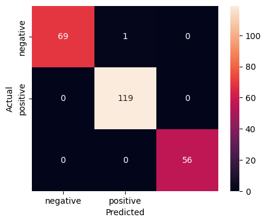

```python
# Predicting on train data
y_pred_train = rf_glove.predict(X_train_gl)
plot_confusion_matrix(y_train, y_pred_train)
```

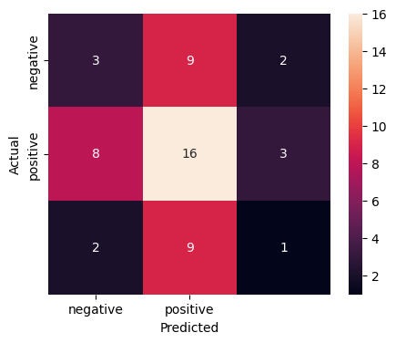

```python
# Predicting on validation data
y_pred_val = rf_glove.predict(X_val_gl)
plot_confusion_matrix(y_val, y_pred_val)
```

### Random Forest with Sentence Transformer

```python
# Building the model
rf_transformer = RandomForestClassifier(n_estimators = 100, max_depth = 7, random_state = 42)

# Fitting on train data
rf_transformer.fit(X_train_st, y_train)
```

```
RandomForestClassifier(max_depth=7, random_state=42)
```

```python
modeldesc="Random Forest"
word_embedding="Sentence Transformer"
training_df = model_performance(rf_transformer, X_train_st, y_train,modeldesc,word_embedding)
validation_df = model_performance(rf_transformer, X_val_st, y_val,modeldesc,word_embedding)


training_results = pd.concat([training_results,training_df], ignore_index=True)
validation_results = pd.concat([validation_results, validation_df], ignore_index=True)
```

**Training and Validation Performance**

```python
training_results[(training_results["Model"]==modeldesc) & (training_results["Word Embedding"]==word_embedding)]
```

|  | Model | Word Embedding | Accuracy | Recall | Precision | F1 |
| --- | --- | --- | --- | --- | --- | --- |
| 2 | Random Forest | Sentence Transformer | 1.0 | 1.0 | 1.0 | 1.0 |

```python
validation_results[(validation_results["Model"]==modeldesc) & (validation_results["Word Embedding"]==word_embedding)]
```

|  | Model | Word Embedding | Accuracy | Recall | Precision | F1 |
| --- | --- | --- | --- | --- | --- | --- |
| 2 | Random Forest | Sentence Transformer | 0.471698 | 0.471698 | 0.437473 | 0.411321 |

- Like both the Word2Vec and GloVe models, the Sentence Transformer model also exhibits severe overfitting based on perfect training scores.
- Its validation F1-score (around 0.41) is comparable with the base Word2Vec model (around 0.41) and higher than the GloVe model (around 0.35).

**Confusion Matrix**

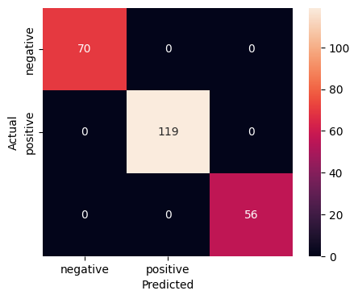

```python
# Predicting on train data
y_pred_train = rf_transformer.predict(X_train_st)

plot_confusion_matrix(y_train, y_pred_train)
```

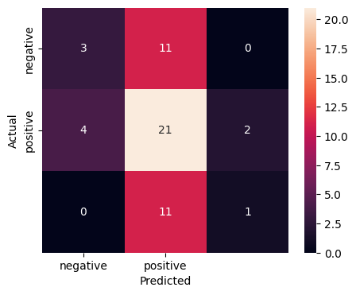

```python
# Predicting on validation data
y_pred_val = rf_transformer.predict(X_val_st)
plot_confusion_matrix(y_val, y_pred_val)
```

### Tuned - Random Forest with Word2Vec

```python
%%time
# show progress

# Choose the type of classifier.
rf1_wv = RandomForestClassifier(random_state=42)

# Grid of parameters to choose from
parameters = {"n_estimators": [100,150,200,250],
    "min_samples_leaf": np.arange(5, 10),
    "max_features": np.arange(0.2, 0.7, 0.1),
    "max_samples": np.arange(0.3, 0.7, 0.1),
    "class_weight" : ['balanced', 'balanced_subsample'],
    "max_depth":np.arange(3,4,5),
    "min_impurity_decrease":[0.001, 0.002, 0.003]
             }

# Type of scoring used to compare parameter combinations
scorer = 'f1_weighted'

# Run the grid search
grid_obj = GridSearchCV(rf1_wv, parameters, scoring=scorer, cv=5, n_jobs= -1, verbose = 2)
# verbose = 2 tells about the number of fits, which can give an idea of how long will the model take in tuning
# n_jobs = -1 so that all CPU cores can be run parallelly to optimize the Search

grid_obj = grid_obj.fit(X_train_wv, y_train)

# Print the best combination of parameters
grid_obj.best_params_
```

```
Fitting 5 folds for each of 2400 candidates, totalling 12000 fits
CPU times: user 42.7 s, sys: 4.27 s, total: 47 s
Wall time: 18min 2s
```

```
{'class_weight': 'balanced_subsample',
 'max_depth': 3,
 'max_features': 0.4000000000000001,
 'max_samples': 0.4,
 'min_impurity_decrease': 0.001,
 'min_samples_leaf': 7,
 'n_estimators': 200}
```

```python
# Set the clf to the best combination of parameters
rf_word2vec_tuned = RandomForestClassifier(
    class_weight="balanced_subsample",
    max_features=0.4000000000000001,
    max_samples=0.4,
    min_samples_leaf=7,
    n_estimators=200,
    max_depth=3,
    random_state=42,
    min_impurity_decrease=0.001,
)

# Fit the best algorithm to the data.
rf_word2vec_tuned.fit(X_train_wv, y_train)
```

```
RandomForestClassifier(class_weight='balanced_subsample', max_depth=3,
                       max_features=0.4000000000000001, max_samples=0.4,
                       min_impurity_decrease=0.001, min_samples_leaf=7,
                       n_estimators=200, random_state=42)
```

```python
modeldesc="Random Forest - Tuned"
word_embedding="Word2Vec"
training_df = model_performance(rf_word2vec_tuned, X_train_wv, y_train,modeldesc,word_embedding)
validation_df = model_performance(rf_word2vec_tuned, X_val_wv, y_val,modeldesc,word_embedding)


training_results = pd.concat([training_results,training_df], ignore_index=True)
validation_results = pd.concat([validation_results, validation_df], ignore_index=True)
```

**Training and Validation Performance**

```python
training_results[(training_results["Model"]==modeldesc) & (training_results["Word Embedding"]==word_embedding)]
```

|  | Model | Word Embedding | Accuracy | Recall | Precision | F1 |
| --- | --- | --- | --- | --- | --- | --- |
| 3 | Random Forest - Tuned | Word2Vec | 0.75102 | 0.75102 | 0.755819 | 0.752285 |

```python
validation_results[(validation_results["Model"]==modeldesc) & (validation_results["Word Embedding"]==word_embedding)]
```

|  | Model | Word Embedding | Accuracy | Recall | Precision | F1 |
| --- | --- | --- | --- | --- | --- | --- |
| 3 | Random Forest - Tuned | Word2Vec | 0.490566 | 0.490566 | 0.511321 | 0.493238 |

- Compared to the untuned Random Forest with Word2Vec, the tuned model shows a modest improvement in generalization.
- The validation F1-score increased from approximately 0.41 in the untuned model to around 0.49 after tuning, suggesting that hyperparameter optimization provided a slight benefit for performance on unseen stock market news sentiment.
- Overfitting is still present (training F1 is around 0.75), but the gap between training and validation performance has narrowed compared to the base model.

**Confusion Matrix**

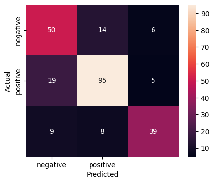

```python
# Predicting on train data
y_pred_train = rf_word2vec_tuned.predict(X_train_wv)
plot_confusion_matrix(y_train, y_pred_train)
```

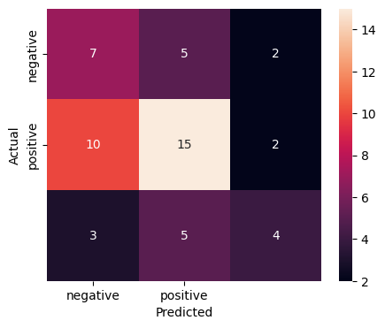

```python
# Predicting on validation data
y_pred_val = rf_word2vec_tuned.predict(X_val_wv)
plot_confusion_matrix(y_val, y_pred_val)
```

### Tuned - Random Forest with Glove

```python
%%time

# Choose the type of classifier.
rf1_gl = RandomForestClassifier(random_state=42)

# Grid of parameters to choose from
parameters = {"n_estimators": [100,150,200,250],
    "min_samples_leaf": np.arange(5, 10),
    "max_features": np.arange(0.2, 0.7, 0.1),
    "max_samples": np.arange(0.3, 0.7, 0.1),
    "class_weight" : ['balanced', 'balanced_subsample'],
    "max_depth":np.arange(3,4,5),
    "min_impurity_decrease":[0.001, 0.002, 0.003]
             }

# Type of scoring used to compare parameter combinations
scorer = 'f1_weighted'

# Run the grid search
grid_obj = GridSearchCV(rf1_gl, parameters, scoring=scorer, cv=5, n_jobs= -1, verbose = 2)
# verbose = 2 tells about the number of fits, which can give an idea of how long will the model take in tuning
# n_jobs = -1 so that all CPU cores can be run parallelly to optimize the Search

grid_obj = grid_obj.fit(X_train_gl, y_train)

# Print the best combination of parameters
grid_obj.best_params_
```

```
Fitting 5 folds for each of 2400 candidates, totalling 12000 fits
CPU times: user 38.5 s, sys: 2.68 s, total: 41.2 s
Wall time: 11min 50s
```

```
{'class_weight': 'balanced_subsample',
 'max_depth': 3,
 'max_features': 0.6000000000000001,
 'max_samples': 0.5,
 'min_impurity_decrease': 0.001,
 'min_samples_leaf': 7,
 'n_estimators': 100}
```

```python
# Set the clf to the best combination of parameters
rf_gl_tuned = RandomForestClassifier(
    class_weight="balanced_subsample",
    max_features=0.6000000000000001,
    max_samples=0.5,
    min_samples_leaf=7,
    n_estimators=100,
    max_depth=3,
    random_state=42,
    min_impurity_decrease=0.001,
)

# Fit the best algorithm to the data.
rf_gl_tuned.fit(X_train_gl, y_train)
```

```
RandomForestClassifier(class_weight='balanced_subsample', max_depth=3,
                       max_features=0.6000000000000001, max_samples=0.5,
                       min_impurity_decrease=0.001, min_samples_leaf=7,
                       random_state=42)
```

```python
modeldesc="Random Forest - Tuned"
word_embedding="Glove"
training_df = model_performance(rf_gl_tuned, X_train_gl, y_train,modeldesc,word_embedding)
validation_df = model_performance(rf_gl_tuned, X_val_gl, y_val,modeldesc,word_embedding)


training_results = pd.concat([training_results,training_df], ignore_index=True)
validation_results = pd.concat([validation_results, validation_df], ignore_index=True)
```

**Training and Validation Performance**

```python
training_results[(training_results["Model"]==modeldesc) & (training_results["Word Embedding"]==word_embedding)]
```

|  | Model | Word Embedding | Accuracy | Recall | Precision | F1 |
| --- | --- | --- | --- | --- | --- | --- |
| 4 | Random Forest - Tuned | Glove | 0.759184 | 0.759184 | 0.767555 | 0.760442 |

```python
validation_results[(validation_results["Model"]==modeldesc) & (validation_results["Word Embedding"]==word_embedding)]
```

|  | Model | Word Embedding | Accuracy | Recall | Precision | F1 |
| --- | --- | --- | --- | --- | --- | --- |
| 4 | Random Forest - Tuned | Glove | 0.339623 | 0.339623 | 0.343251 | 0.341274 |

- Tuning the Random Forest with GloVe embeddings significantly reduced overfitting on the training data (F1 improved from ~0.996 to ~0.76).
- The validation F1-score remained similarly low (around 0.35 initially vs. ~0.34 after tuning), suggesting that the tuning process did not effectively improve the model's ability to generalize to unseen stock market news sentiment.

**Confusion Matrix**

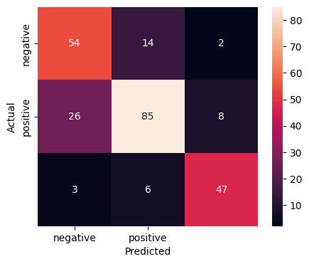

```python
# Predicting on train data
y_pred_train = rf_gl_tuned.predict(X_train_gl)
plot_confusion_matrix(y_train, y_pred_train)
```

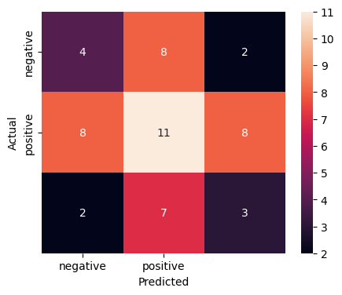

```python
# Predicting on validation data
y_pred_val = rf_gl_tuned.predict(X_val_gl)
plot_confusion_matrix(y_val, y_pred_val)
```

### Tuned - Random Forest with Sentence Transformer

```python
%%time

# Choose the type of classifier.
rf1_st = RandomForestClassifier(random_state=42)

# Grid of parameters to choose from
parameters = {"n_estimators": [100,150,200,250],
    "min_samples_leaf": np.arange(5, 10),
    "max_features": np.arange(0.2, 0.7, 0.1),
    "max_samples": np.arange(0.3, 0.7, 0.1),
    "class_weight" : ['balanced', 'balanced_subsample'],
    "max_depth":np.arange(3,4,5),
    "min_impurity_decrease":[0.001, 0.002, 0.003]
             }

# Type of scoring used to compare parameter combinations
scorer = 'f1_weighted'

# Run the grid search
grid_obj = GridSearchCV(rf1_st, parameters, scoring=scorer, cv=5, n_jobs= -1, verbose = 2)
# verbose = 2 tells about the number of fits, which can give an idea of how long will the model take in tuning
# n_jobs = -1 so that all CPU cores can be run parallelly to optimize the Search

grid_obj = grid_obj.fit(X_train_st, y_train)

# Print the best combination of parameters
grid_obj.best_params_
```

```
Fitting 5 folds for each of 2400 candidates, totalling 12000 fits
CPU times: user 40.1 s, sys: 3.34 s, total: 43.4 s
Wall time: 20min 53s
```

```
{'class_weight': 'balanced_subsample',
 'max_depth': 3,
 'max_features': 0.2,
 'max_samples': 0.4,
 'min_impurity_decrease': 0.001,
 'min_samples_leaf': 8,
 'n_estimators': 100}
```

```python
# Set the clf to the best combination of parameters
rf_st_tuned = RandomForestClassifier(
    class_weight="balanced_subsample",
    max_features=0.2,
    max_samples=0.4,
    min_samples_leaf=8,
    n_estimators=100,
    max_depth=3,
    random_state=42,
    min_impurity_decrease=0.001,
)

# Fit the best algorithm to the data.
rf_st_tuned.fit(X_train_st, y_train)
```

```
RandomForestClassifier(class_weight='balanced_subsample', max_depth=3,
                       max_features=0.2, max_samples=0.4,
                       min_impurity_decrease=0.001, min_samples_leaf=8,
                       random_state=42)
```

```python
modeldesc="Random Forest - Tuned"
word_embedding="Sentence Transformer"
training_df = model_performance(rf_st_tuned, X_train_st, y_train,modeldesc,word_embedding)
validation_df = model_performance(rf_st_tuned, X_val_st, y_val,modeldesc,word_embedding)


training_results = pd.concat([training_results,training_df], ignore_index=True)
validation_results = pd.concat([validation_results, validation_df], ignore_index=True)
```

**Training and Validation Performance**

```python
training_results[(training_results["Model"]==modeldesc) & (training_results["Word Embedding"]==word_embedding)]
```

|  | Model | Word Embedding | Accuracy | Recall | Precision | F1 |
| --- | --- | --- | --- | --- | --- | --- |
| 5 | Random Forest - Tuned | Sentence Transformer | 0.885714 | 0.885714 | 0.886057 | 0.885598 |

```python
validation_results[(validation_results["Model"]==modeldesc) & (validation_results["Word Embedding"]==word_embedding)]
```

|  | Model | Word Embedding | Accuracy | Recall | Precision | F1 |
| --- | --- | --- | --- | --- | --- | --- |
| 5 | Random Forest - Tuned | Sentence Transformer | 0.396226 | 0.396226 | 0.360488 | 0.369353 |

- Tuned model demonstrates a similar level of generalization to unseen data compared to the base (untuned) Random Forest with Sentence Transformer.
- Its validation F1-score (around 0.37) is comparable to the base model's validation F1-score (around 0.41), suggesting that hyperparameter tuning did not significantly improve the model's ability to classify unseen stock market news sentiment with Sentence Transformer embeddings.

**Confusion Matrix**

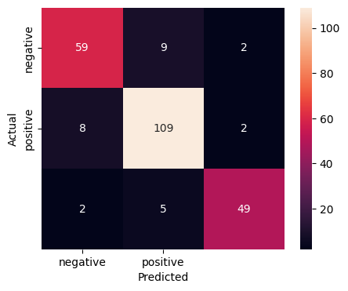

```python
# Predicting on train data
y_pred_train = rf_st_tuned.predict(X_train_st)
plot_confusion_matrix(y_train, y_pred_train)
```

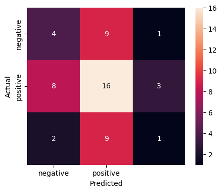

```python
# Predicting on validation data
y_pred_val = rf_st_tuned.predict(X_val_st)
plot_confusion_matrix(y_val, y_pred_val)
```